# Animal activity: a very simple guide

[figure not shown]

### Francisco E. Fontúrbel & H. Javier Cuadra

This repository contains useful code and example data on how to study and test hypotheses on animal activity.

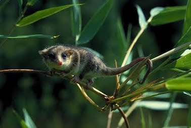

*Dromiciops gliroides*

Here we collected code from ongoing work at the lab (projects, dissertations, etc.) aiming to have a common source of analysis code to this purpose, free to use for anyone.

This repository has three chapters (so far):

**01.- Introduction**. A brief introduction on animal activity (still under development, please be patience).

**02.- Circular statistics**. How to deal with time data using circular statistics, how to plot them and hypothesis-test.

**03.- Kernel density estimators**. Kernel density functions derived from activity data, including plots and hypothesis testing.

### [TOGGLE TO GITHUB VERSION](https://github.com/fonturbel-lab/AnimActivity)

#### Please cite this material as:

Fontúrbel, F.E. & H.J. Cuadra. 2019. Animal activity: a very simple guide. GitHub repository, doi: 10.5281/zenodo.3345231

### Terms of use

This information is provided under a Creative Commons BY-SA license. Therefore, you may freely use this material, but you must (i) give the appropriate credit to the authors by citing this repository and its doi, and (ii) if you transform, remix, or build upon this data, the resulting dataset should be shared under the same license conditions.